# Astronauts

Rob Wiederstein

2021-02-06

# Introduction

This project was based on the astronaut [dataset](https://www.kaggle.com/jessemostipak/astronaut-database) at kaggle. Credit for the dataset was given to Georgios Karamanis. The sources were listed as NASA, Roscosmos and “fun-made” websites.

“EVA” is an abbreviation for “extra-vehicular-activity,” and is used to describe astonaut activities outside the main capsule like space walks. `field21` is an unknown field.

# Preliminaries

## Missingness

Let’s check for missingness. 9 values are missing. Subsetting to only the rows that contain a missing value yields the dataframe below.

```r
df.na <- df[!complete.cases(df), ]
df.na[, 1:5] #first five columns
```

| id | number | nationwide_number | name | original_name |
| --- | --- | --- | --- | --- |
| 186 | 87 | 1 | Vladimir Remek | NA |
| 198 | 94 | 1 | Bertalan Farkas | Farkas Bertalan |
| 369 | 173 | 1 | Al-saud, Sultan bin Salman | NA |
| 416 | 195 | 1 | Neri Vela, Rodolfl | NA |
| 438 | 205 | 1 | Faris, M. Achmed | NA |
| 450 | 211 | 1 | Mohmand, Abdul Ahad | NA |
| 1067 | 440 | 277 | Olsen, Gregory Hammond | Olsen, Gregory Hammond |
| 1238 | 532 | 6 | Parmitano, Luca | Parmitano, Luca |

Also, the missing values in the variables might reveal a pattern. The `Amelia` package contains a quick way to plot missing data.

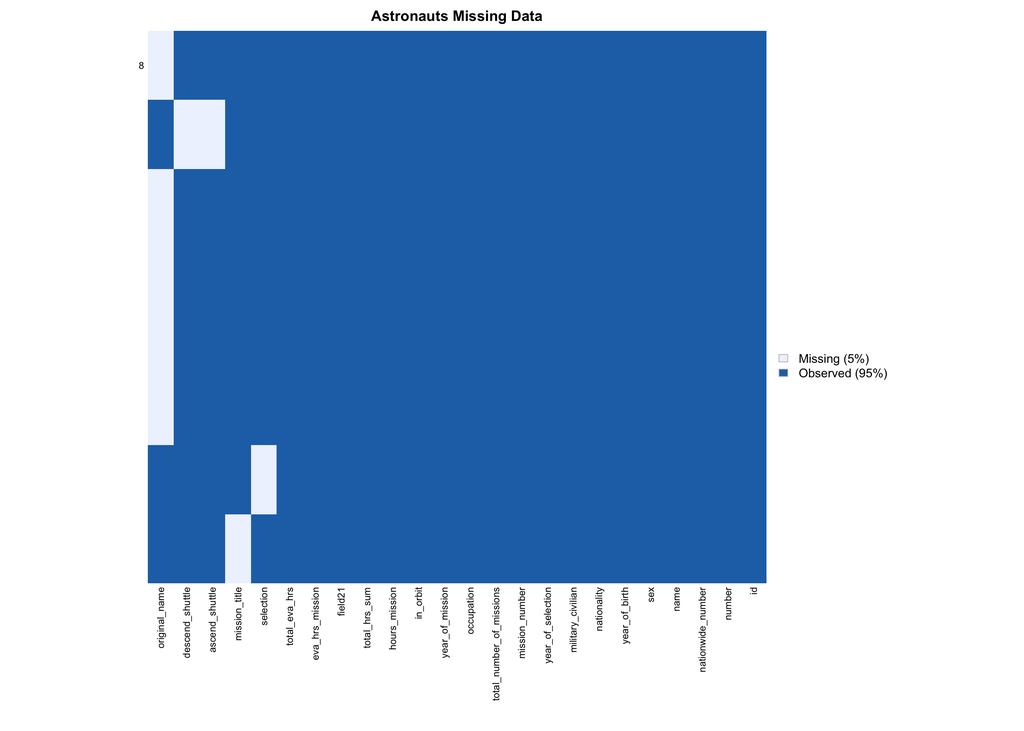

```r
Amelia::missmap(df.na,
                margins = c(10, 10),
                main = "Astronauts Missing Data")
```

Of the nine missing values, five are in the variable `original_name`. The missing value in the `mission_title` variable may prove problematic. The variable will be used to group the astronauts later in the analysis for a social network diagram.

## Unique values

Also, counting the unique values within each column could identify potential factor variables. The `id` field is clearly a unique identifier for each row. It also appears that each astronaut has a unique identifier in the `number` field in addition to the `name` field. The `sex`, `military_civilian` and `nationality` variables could yield some interesting comparisons.

```r
rev(sort(apply(df, 2, function(x) length(unique(x)))))
```

```
                      id                     name                   number
                    1277                      564                      564
           original_name            total_hrs_sum            hours_mission
                     561                      494                      471
          ascend_shuttle          descend_shuttle            mission_title
                     437                      433                      362
       nationwide_number                 in_orbit          eva_hrs_mission
                     346                      289                      262
               selection            total_eva_hrs            year_of_birth
                     230                      216                       60
         year_of_mission        year_of_selection              nationality
                      59                       47                       40
              occupation                  field21 total_number_of_missions
                      12                        8                        7
          mission_number        military_civilian                      sex
                       7                        2                        2
```

## Variable Types

```r
my_vars <- lapply(df, class)
df.vars <- data.frame(variables = names(my_vars),
                 values = unlist(lapply(my_vars, "[[", 1))
)
row.names(df.vars) <- NULL
df.vars %>% dplyr::arrange(values)
```

| variables | values |
| --- | --- |
| name | character |
| original_name | character |
| sex | character |
| nationality | character |
| military_civilian | character |
| selection | character |
| occupation | character |
| mission_title | character |
| ascend_shuttle | character |
| in_orbit | character |

[output cut: 14 more lines]

```r
NA
NA
```

## Summary

```r
str(df, give.attr = F)
```

```
tibble [1,277 × 24] (S3: spec_tbl_df/tbl_df/tbl/data.frame)
 $ id                      : num [1:1277] 1 2 3 4 5 6 7 8 9 10 ...
 $ number                  : num [1:1277] 1 2 3 3 4 5 5 6 6 7 ...
 $ nationwide_number       : num [1:1277] 1 2 1 1 2 2 2 4 4 3 ...
 $ name                    : chr [1:1277] "Gagarin, Yuri" "Titov, Gherman" "Glenn, John H., Jr." "Glenn, John H., Jr." ...
 $ original_name           : chr [1:1277] "ГАГАРИН Юрий Алексеевич" "ТИТОВ Герман Степанович" "Glenn, John H., Jr." "Glenn, John H., Jr." ...
 $ sex                     : chr [1:1277] "male" "male" "male" "male" ...
 $ year_of_birth           : num [1:1277] 1934 1935 1921 1921 1925 ...
 $ nationality             : chr [1:1277] "U.S.S.R/Russia" "U.S.S.R/Russia" "U.S." "U.S." ...
 $ military_civilian       : chr [1:1277] "military" "military" "military" "military" ...
 $ selection               : chr [1:1277] "TsPK-1" "TsPK-1" "NASA Astronaut Group 1" "NASA Astronaut Group 2" ...
 $ year_of_selection       : num [1:1277] 1960 1960 1959 1959 1959 ...
 $ mission_number          : num [1:1277] 1 1 1 2 1 1 2 1 2 1 ...
 $ total_number_of_missions: num [1:1277] 1 1 2 2 1 2 2 2 2 3 ...
 $ occupation              : chr [1:1277] "pilot" "pilot" "pilot" "PSP" ...
 $ year_of_mission         : num [1:1277] 1961 1961 1962 1998 1962 ...
 $ mission_title           : chr [1:1277] "Vostok 1" "Vostok 2" "MA-6" "STS-95" ...
 $ ascend_shuttle          : chr [1:1277] "Vostok 1" "Vostok 2" "MA-6" "STS-95" ...
 $ in_orbit                : chr [1:1277] "Vostok 2" "Vostok 2" "MA-6" "STS-95" ...
 $ descend_shuttle         : chr [1:1277] "Vostok 3" "Vostok 2" "MA-6" "STS-95" ...
 $ hours_mission           : num [1:1277] 1.77 25 5 213 5 ...
 $ total_hrs_sum           : num [1:1277] 1.77 25.3 218 218 5 ...
 $ field21                 : num [1:1277] 0 0 0 0 0 0 0 0 0 0 ...
 $ eva_hrs_mission         : num [1:1277] 0 0 0 0 0 0 0 0 0 0 ...
 $ total_eva_hrs           : num [1:1277] 0 0 0 0 0 0 0 0 0 0 ...
```

# Challenges

There was some difficulty in the data which was discovered when creating a network analysis. The names were problematic. “Aleksandrov, Aleksandr”, a Russian astronaut, appears to be the same person but is in the astronaut subset twice. The other issue is that two astronauts have been assigned the number “385”: Yuri Baturin and Pedro Duque. This challenge will be set aside for the time being.

```r
df2 <- df[, c(2, 4)] #subset main df to just astronaut and number
df2 <- dplyr::distinct(df2)
print(paste(nrow(df2), "number of distinct astronauts"))
```

```
[1] "565 number of distinct astronauts"
```

```r
#one astronaut is included in the names column twice--it is the same person
duplicate.name <- df2$name[duplicated(df2$name)]
df2[grep(duplicate.name, df2$name), ]
```

| number | name |
| --- | --- |
| 123 | Aleksandrov, Aleksandr |
| 209 | Aleksandrov, Aleksandr |

```r
NA
```

```r
#two astronauts have the same number
duplicate.number <- df2$number[duplicated(df2$number)]
df2[which(df2$number == duplicate.number), ]
```

| number | name |
| --- | --- |
| 385 | Baturin, Yuri |
| 385 | Duque, Pedro |

# Correlation Among Variables

Subsetting the main dataframe to the numeric variables yields an unsurprising set of correlations.

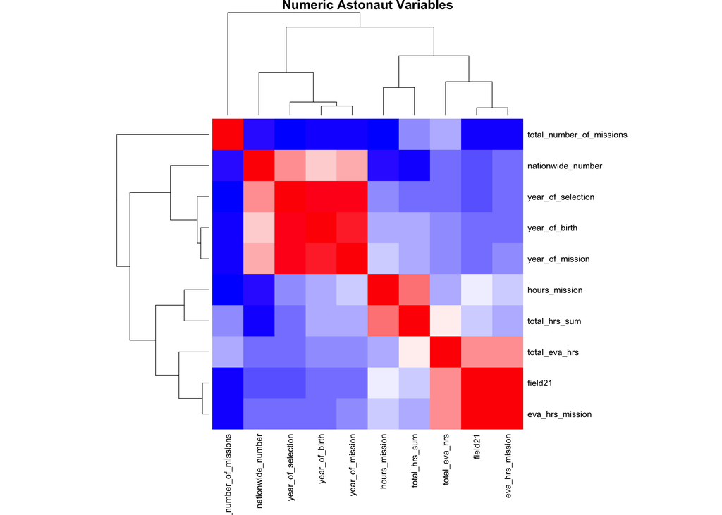

```r
df3 <- dplyr::select_if(df, is.numeric)
df3 <- dplyr::select(df3, -id, -number, -mission_number)
res <- cor(df3)
res <- round(res, 2)
library(corrplot)
col<- colorRampPalette(c("blue", "white", "red"))(20)
heatmap(x = res, col = col,
        symm = TRUE,
        margins = c(10, 10),
        main = "Numeric Astonaut Variables")
```

# Descriptive Plots

## Interesting Univariate Distributions

Two of the more interesting distributions in the variables were `hours_mission` and `total_hrs_sum`. A great number of outliers were evident in both the variables, meaning multiple astronauts have spent an extensive period of time in space.

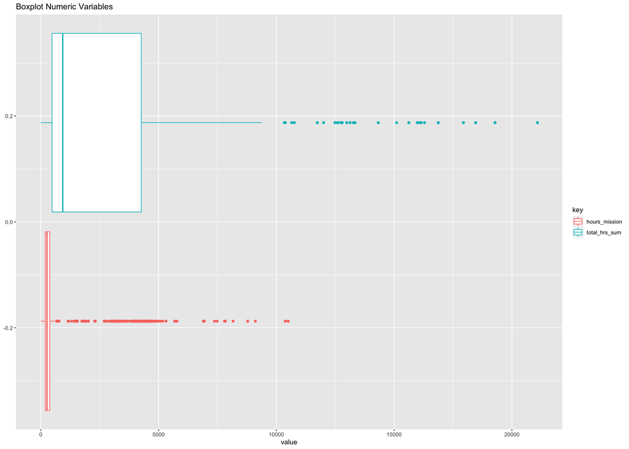

```r
df4 <- dplyr::select_if(df, is.numeric)
df4 <- dplyr::select(df4, hours_mission, total_hrs_sum)
df4 <- tidyr::gather(df4)
library(ggplot2)
p <- ggplot(df4, aes(value, group = key, colour = key))
p <- p + geom_boxplot()
p <- p + ggtitle("Boxplot Numeric Variables")
p
```

## Flights by year and gender

While the vast majority of astronauts have been male, the age distributions between the sexes is relatively the same though.

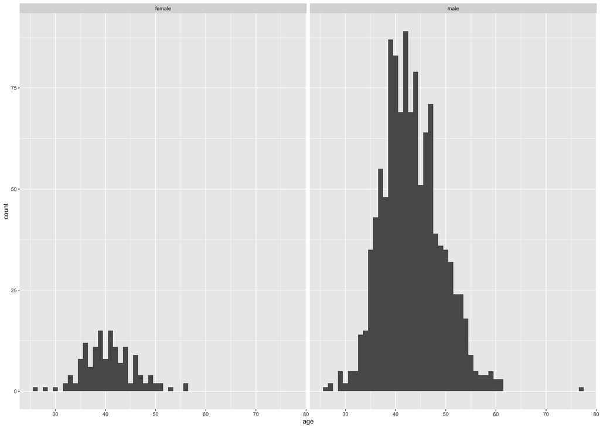

```r
df$age <- df$year_of_mission - df$year_of_birth
df5 <-
        df %>%
        select(name, age, sex)
p <- ggplot(df5, aes(age))
p <- p + geom_histogram(binwidth = 1)
p <- p + facet_grid(. ~ sex)
p
```

## Space Flights by Year (U.S. & Russia)

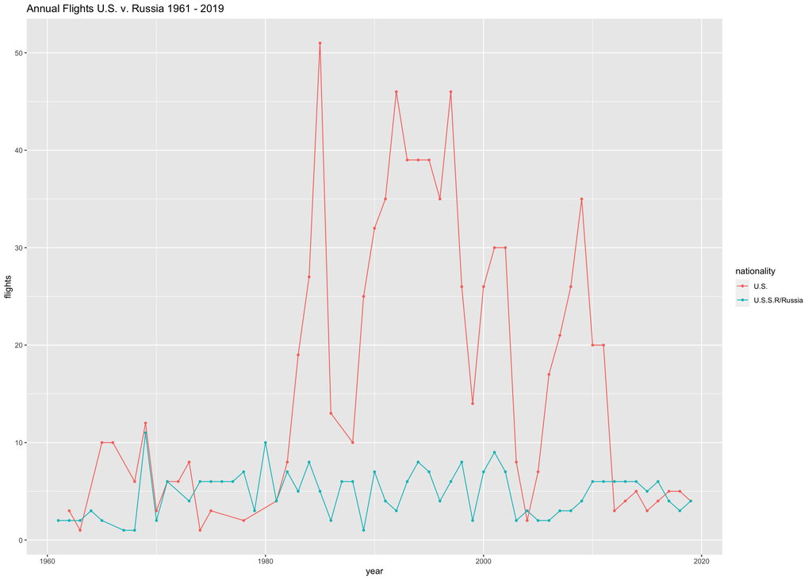

```r
df$num <- 1
df6 <-
        df %>%
        dplyr::filter(nationality %in% c("U.S.S.R/Russia", "U.S.")) %>%
        group_by(year_of_mission, nationality) %>%
        summarize(flights = sum(num))
colnames(df6)[1] <- "year"
p <- ggplot(df6, aes(year, flights, group = nationality, color = nationality))
p <- p + geom_line()
p <- p + geom_point(size = 1)
p <- p + ggtitle(paste("Annual Flights U.S. v. Russia 1961 - 2019"))
p
```

## Astronauts Ranked by Total Hours

```r
df7 <-
        df %>%
        select(name, nationality, sex, year_of_birth, total_hrs_sum) %>%
        arrange(-total_hrs_sum) %>%
        distinct() %>%
        dplyr::slice_head(n = 10)
df7
```

| name | nationality | sex | year_of_birth | total_hrs_sum |
| --- | --- | --- | --- | --- |
| Padalka, Gennady | U.S.S.R/Russia | male | 1958 | 21083.52 |
| Krikalev, Sergei | U.S.S.R/Russia | male | 1958 | 19281.65 |
| Kaleri, Aleksandr | U.S.S.R/Russia | male | 1956 | 18462.62 |
| Avdeyev, Sergei | U.S.S.R/Russia | male | 1956 | 17942.23 |
| Malenchenko, Yuri | U.S.S.R/Russia | male | 1961 | 16872.47 |
| Polyakov, Valeri | U.S.S.R/Russia | male | 1942 | 16288.53 |
| Yurchikhin, Fyodor | U.S.S.R/Russia | male | 1959 | 16147.00 |
| Kononenko, Oleg D. | U.S.S.R/Russia | male | 1964 | 16081.00 |
| Whitson, Peggy A. | U.S. | female | 1960 | 15982.00 |
| Solovyev, Anatoly | U.S.S.R/Russia | male | 1948 | 15624.03 |

# Social Nework Analysis

## The Space Race

The “Space Race” was a competition between two Cold War rivals: the United States and the U.S.S.R. The race began in 1955 when the U.S. announced its intent to launch four orbiting satellites. The U.S.S.R. successfully preempted the U.S. by launching the first orbiting satellite, Sputnik I. The U.S.S.R. also sent the first human to space, Yuri Gagarin, on April 12, 1961. The height of the race was the U.S. landing the first person on the moon on July 20, 1969. The mission was “Apollo 11.” See the Wikipedia [article](https://en.wikipedia.org/wiki/Space_Race).

Below the astronaut database was subset to the space flights from 1961 to 1969. Since no other countries had the capability or desire to participate and because there was a limited number of flights, the smaller dataset was easier to experiment with and the astronaut names are familiar to most.

The nodes represent individual astronauts and they are grouped by mission. The size of the node represents the number of missions of each astronaut over his or her career.

### Edge list

```r
space_race <- min(df$year_of_mission): 1969
#subset
df.1 <- dplyr::filter(df, year_of_mission %in% space_race)
#create edge list
df.2 <-
        df.1 %>%
        select(mission_title, name) %>%
        inner_join(., select(., mission_title, name), by = "mission_title") %>%
        rename(name1 = name.x, name2 = name.y) %>%
        dplyr::filter(name1 != name2) %>%
        arrange(mission_title) %>%
        unique

#edge list dataframe
df.3 <- dplyr::select(df.2, name1, name2,  mission_title)
head(df.3)
```

| name1 | name2 | mission_title |
| --- | --- | --- |
| Young, John W. | Stafford, Thomas P. | Apollo 10 |
| Young, John W. | Cernan, Eugene A. | Apollo 10 |
| Stafford, Thomas P. | Young, John W. | Apollo 10 |
| Stafford, Thomas P. | Cernan, Eugene A. | Apollo 10 |
| Cernan, Eugene A. | Young, John W. | Apollo 10 |
| Cernan, Eugene A. | Stafford, Thomas P. | Apollo 10 |

### Nodes

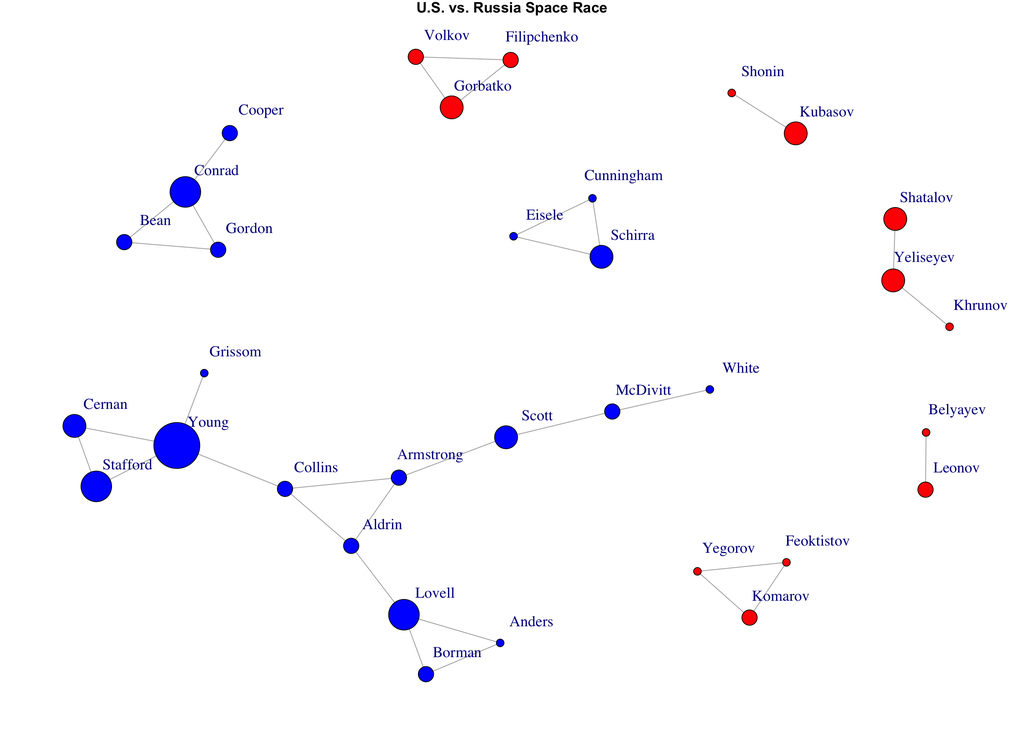

```r
#nodes
nodes <- tibble(name = unique(c(df.3$name1, df.3$name2)))
nodes.1 <- dplyr::left_join(nodes, df.1, by = "name")
nodes.1 <- nodes.1[-which(duplicated(nodes.1$name) == TRUE), ]
#add nationality
nodes.1$nationality_col <- "blue"
nodes.1$nationality_col[grep("Russia", nodes.1$nationality)] <- "red"
#add lastname
nodes.1$last_name <- gsub(",", "", word(nodes.1$name))
#graph
g <- graph_from_data_frame(df.3,
                           directed = FALSE,
                           vertices = nodes.1)
g1 <- igraph::simplify(g)
par(mar = c(1, 1, 1, 1))
set.seed(123)
plot(g1,
     layout = layout_with_fr,
     vertex.color = V(g1)$nationality_col,
     vertex.size = V(g1)$total_number_of_missions * 1.75,
     vertex.label = V(g1)$last_name,
     vertex.label.dist = 1.4,
     vertex.label.cex = 1.25,
     asp = 0,
     main = "U.S. vs. Russia Space Race"
     )
```

## All Astronauts

Having accomplished a plot of a subset of the data, it is time to try a broader effort. Below is the creation of the edge list and vertex list for the full set of astronauts grouped by mission title.

### Edge list

```r
df.2 <-
        df %>%
        select(mission_title, name) %>%
        inner_join(., select(., mission_title, name), by = "mission_title") %>%
        rename(name1 = name.x, name2 = name.y) %>%
        dplyr::filter(name1 != name2) %>%
        arrange(mission_title) %>%
        unique

#edge list dataframe
df.3 <- dplyr::select(df.2, name1, name2,  mission_title)
head(df.3)
```

| name1 | name2 | mission_title |
| --- | --- | --- |
| Kizim, Leonid | Solovyov, Vladimir | 1 |
| Kizim, Leonid | Viktorenko, Aleksandr | 1 |
| Kizim, Leonid | Faris, M. Achmed | 1 |
| Kizim, Leonid | Krikalev, Sergei | 1 |
| Kizim, Leonid | Shepherd, William M. | 1 |
| Kizim, Leonid | Gidzenko, Yuri | 1 |

### Nodes

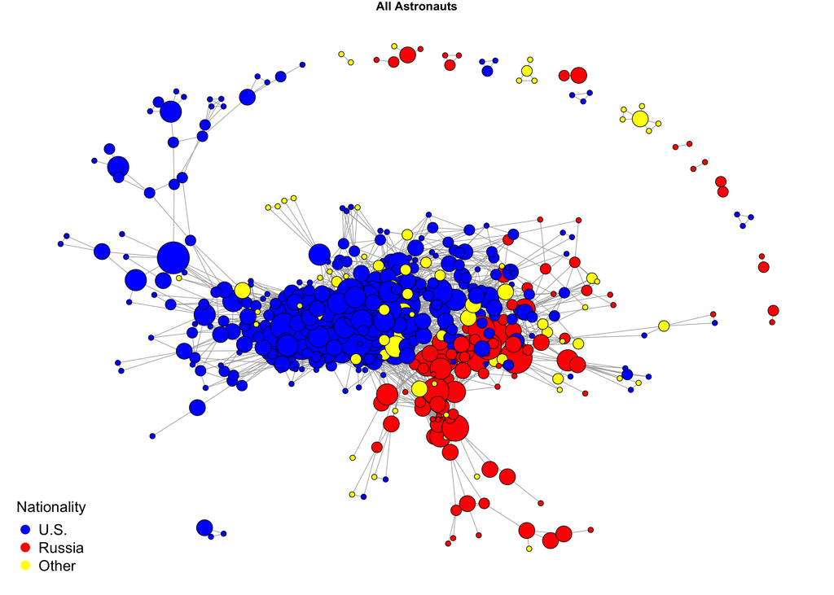

```r
#nodes
nodes <- tibble(name = unique(c(df.3$name1, df.3$name2)))
nodes.1 <- dplyr::left_join(nodes, df, by = "name")
nodes.1 <- nodes.1[-which(duplicated(nodes.1$name) == TRUE), ]
#add nationality as factor
nodes.1 <-
        nodes.1 %>%
        mutate(nationality_f = fct_lump(nationality, n = 2))
#add nationality as color
nodes.1$nationality_col <- "yellow"
nodes.1$nationality_col[grep("U\\.S\\.$", nodes.1$nationality_f)] <- "blue"
nodes.1$nationality_col[grep("Russia", nodes.1$nationality_f)] <- "red"
#graph
g <- graph_from_data_frame(df.3,
                           directed = FALSE,
                           vertices = nodes.1)
g1 <- igraph::simplify(g)
#legend
legend_cats <- data.frame(attr = unique(vertex_attr(g1, "nationality_f")),
                          color = unique(V(g1)$nationality_col))
legend_cats <- legend_cats[order(legend_cats$attr), c(1, 2)]
#plot
par(mar = c(1, 1, 1, 1))
set.seed(123)
plot(g1,
     layout = layout_with_fr,
     vertex.color = V(g1)$nationality_col,
     vertex.size = V(g1)$total_number_of_missions * 1.5,
     vertex.label = NA,
     asp = 0,
     main = "All Astronauts"
     )
legend(x = "bottomleft",      ## position, also takes x,y coordinates
       legend = c("U.S.", "Russia", "Other"), #legend_cats$attr,
       pch = 19,              ## legend symbols see ?points
       col = c("blue", "red", "yellow"),
       bty = "n",
       title = "Nationality",
       cex = 1.5,
       pt.cex = 2)
```

# Conclusion

Some of the challenges in the data did not end up presenting problems in the creation of the social networks. There’s a lot more here to investigate, but as always, time is limited and there are other projects waiting. I would have liked for the nodes to be plotted more broadly, but it was going to take some effort to accomplish it. That’s something I’ll pursue in the future. (It will likely involve the `qgraph` package for those that are interested.) Many thanks to Jesse Mostipak for posting the data set to Kaggle and to George Karamanis for creating it.